# R Training 3

# Introduction

*Note: We will be using the default graphics for some of our plots for conveniance, as **spectro()** uses default graphics and will not allow mulit-plots with ggplot2 generated graphs. There is a **ggspectro()** function, but it is complicated and we will not be using it.*

# Exercise 9: Sperate the syllables in a song

Lets load our data. Remember to load any necessary libraries before you begin.

```r
zf_data = readWave('zfinch.wav')
zfFs = zf_data@samp.rate
tim = seq(1/zfFs, length(zf_data@left)/zfFs, 1/zfFs)
```

We are going to separate the syllables by amplitude. The problem with the original signal is that it goes both up and down, so it is not possible to directly measure the amplitude. Below I describe two methods,“Strategy 1” and “Strategy 2”, that can be used to make a useful measure of the amplitude.

These two methods produce nearly the same result. The first method is to rectify the signal and low-pass filter, and the other is to use a function known as “Hilbert” and low-pass filter.

Both require that the signal be centered at zero. It is easy to do this by subtracting the mean from the original signal.

Lets use the **mean()** function…

```r
zf_data_center = zf_data@left - mean(zf_data@left)
```

## Strategy 1: Rectify and smooth

First lets take the absolute value using **abs()**…

```r
rz = abs(zf_data_center)
```

Now we are going to smooth this signal using a median filter. R does this with the function **runmed()**.

Before we do that lets set our variables. Here **sms** is the duration, in seconds, of the filter - I have set the default to 20 milliseconds. If **sms** is too long, then it will smooth out the signal too much. If **sms** is too short, then you will get spurious syllables. We will multiply **sms** with the sample rate, **Fs**. This will give us the number of samples for the duration that **sms** specifies.

```r
sms = 0.020
zfFs = zf_data@samp.rate
```

The we apply our filter…

```r
mrz = runmed(rz, Fs*sms)
```

```r
mrz = mrz*1000
```

## Strategy 2: Hilbert and Smooth

This is almost identical to Strategy 1, but uses a nice function called **hilbert()**. This function is from the package **seewave**, which you should already have installed!

```r
hz = abs(hilbert(rz, f = Fs))
```

Lets apply the same filter as above.

```r
mhz = runmed(hz, Fs*sms)
mhz = mhz*1000
```

Time to plot. First the original signal…

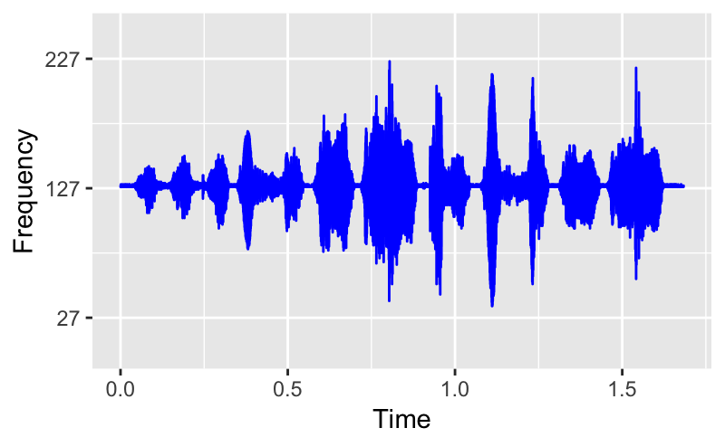

```r
zf_data_plot = data.frame(tim, zf_data@left)
ggplot(zf_data_plot, aes(x = tim, y = zf_data.left)) +
  geom_line(color = "Blue") +
  scale_y_continuous(name = "Frequency", breaks = c(27,127,227), limits = c(0,250)) +
  scale_x_continuous(name = "Time")
```

…and the same signal after filtering.

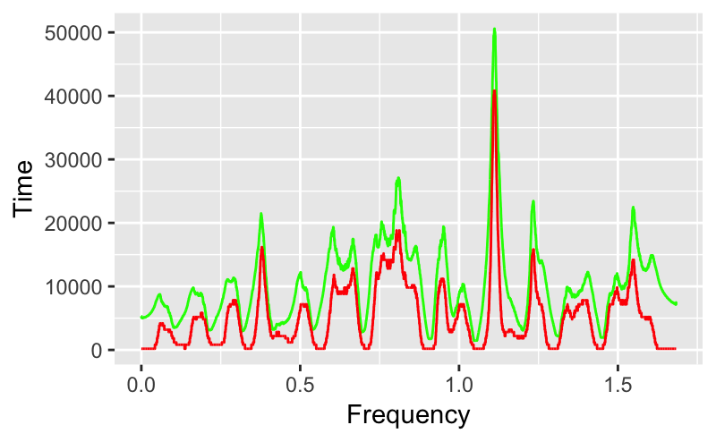

```r
ggplot() +
  geom_line(aes(x = tim, y = mhz), color = "Green") +
  geom_line(aes(x = tim, y = mrz), color = "Red") +
  ylab("Time") +
  xlab("Frequency")
```

## Sepperate the Song into Syllables

Animals often produce signals that are composed of multiple parts. One strategy to understand the signal is to divide it into syllables. That is what we will do here - use an amplitude threshold to separate each part into distinct syllables.

We start by replotting the same data (**mrz**) from the last system, but the **y axis** will be on a log scale. This is acheived using the parameter **scale_y_log10()** which plots with the X axis normal and Y axis on a log scale.

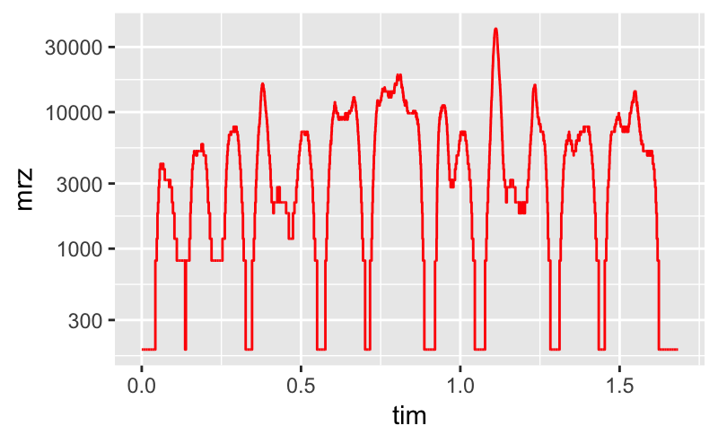

```r
ggplot() +
  geom_line(aes(x = tim, y = mrz), color = "Red") +
  scale_y_log10() +
  theme(legend.position = "none")
```

Now that we’ve plotted our data, need to choose a threshold. We can either look at the plot and guess, or we can click on the plot and the computer will give us the coordinates where we clicked:

### First strategy - I guess “900”!

```r
thresh = 900
```

For clicking, we use the command **locator()** and specify how many clicks we are going to make, which is 1 in this case:

thresh = locator(1)

If we used **locator()**, then **thresh** will have two values, the x-value and the y-value of the click. We only want the y-value, which is in the second position, and hence we only want **thresh[2]**. We can do the following:

thresh = thresh[2]

Let’s replot with a line at the guessed threshold just to check. You might have to redo this section over and over again with different values for **thresh** until we get a value that we think will suffice.

And now we plot the line of our threshold :

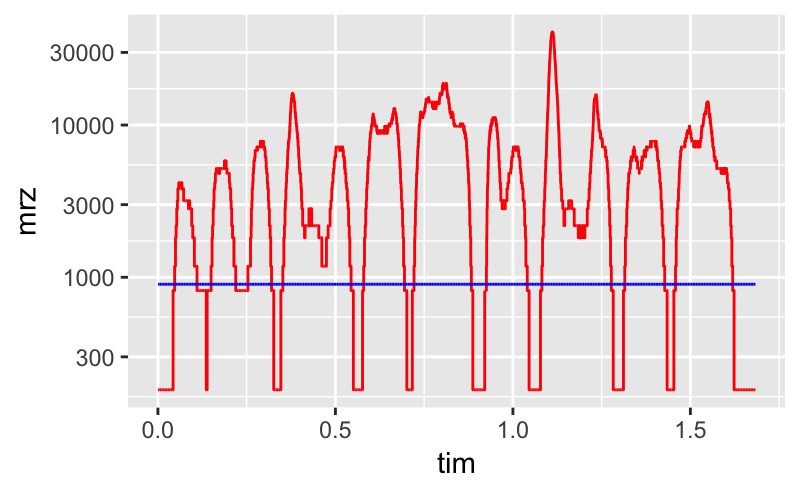

```r
ggplot() +
  geom_line(aes(x = tim, y = mrz), color = "Red") +
  geom_line(aes(x = tim, y = thresh), color = "Blue") +
  scale_y_log10() +
  theme(legend.position = "none")
```

```r
NA
```

Now we use the **which()** command to get the part of the signal above the threshold. The variable **syls** will get the index numbers for each value of **mrz** that is larger than **thresh**:

```r
syls = which(mrz > thresh)
```

Now we’re going to do something that will extract the starts and ends of each syllable. This seems complicated, but it is simple.

The first step is to make a list of zeros that is the length of the signal. We can use the **rep()** command:

```r
zz = rep(0, length((zf_data@left)))
```

Let’s look at **zz**:

Replot the original signal and then plot **zz**.

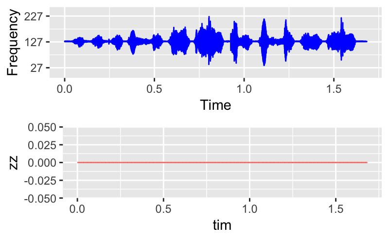

```r
grid.arrange(ggplot(zf_data_plot, aes(x = tim, y = zf_data.left)) +
               geom_line(color = "Blue") +
               scale_y_continuous(name = "Frequency", breaks = c(27,127,227), limits = c(0,250)) +
               scale_x_continuous(name = "Time"),
             ggplot() +
               geom_line(aes(x = tim, y = zz, color = "Red")) +
               theme(legend.position = "none"),
             nrow = 2)
```

From above, **syls** is the list of values that are above the threshold - these are where the syllables are located. We will set **zz** to 1 for each of these values…

```r
zz[syls] = 1
```

Now lets replot **zz**:

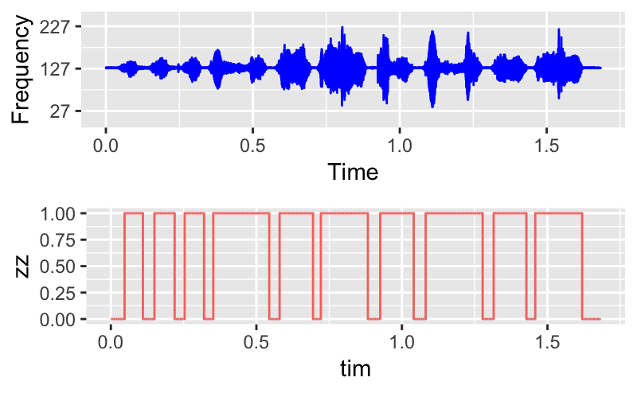

```r
grid.arrange(ggplot(zf_data_plot, aes(x = tim, y = zf_data.left)) +
               geom_line(color = "Blue") +
               scale_y_continuous(name = "Frequency", breaks = c(27,127,227), limits = c(0,250)) +
               scale_x_continuous(name = "Time"),
             ggplot() +
               geom_line(aes(x = tim, y = zz, color = "Red")) +
               theme(legend.position = "none"),
             nrow = 2)
```

Cool - these blocks roughly align with the syllables… but what we need are the start times and end times of the syllables. We will use a trick to get them…

**diff** takes the difference between adjacent values…

*For example sample(2) - sample(1)…*

```r
yy = diff(zz)
yy_tim = tim[1:length(tim)-1]
```

Now let’s plot this. Starts are marked by **1** and ends are marked by **-1**.

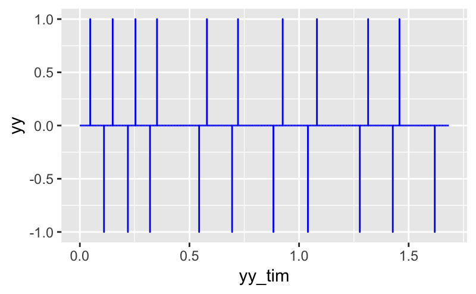

```r
ggplot() +
  geom_line(aes(x = yy_tim, y = yy), color = "Blue")
```

Now we use the **which()** command to get the *starts* and the *ends* of each syllable. Notice that we use **==** to indicate when we are **ASKING** if values are equal, but use **=** to **SET** a variable to a value.

```r
starts = which(yy == 1)
ends = which(yy == -1)
```

Now this is simple! We use a loop - the **for** command to get each syllable. Before we write our loop we will create some empty lists to hold our outputs.

*Note: Loops are generally not recommended in R, but here it is fairly simple and makes ourlives easier.*

```r
syllable = c()
timmy = c()
timm = c()
for (i in seq(1,length(starts))) {
  syllable[[i]] = zf_data@left[starts[i]:ends[i]]
  timmy[[i]] = tim[starts[i]:ends[i]]
  timm[[i]] = seq(1/Fs, (1 + ends[i] - starts[i])/Fs, 1/Fs)
}
```

**syllable[1]** will have the entire 1st syllable, **syllable[2]** will have the entire 2nd syllable, etc.

*Note: timmy and timm are not necessary, but might be useful. **timmy** is the real times from the song. **timm** is the time of the syllable from 0*

Just to show what has happened, here is a plot:

```r
par(mfrow = c(2,4))
specplot(syllable[[4]], Fs = zfFs)
specplot(syllable[[5]], Fs = zfFs)
```

```r
specplot(syllable[[6]], Fs = zfFs)
specplot(syllable[[7]], Fs = zfFs)
```

```r
plot(timmy[[4]], syllable[[4]], type = "l", col = "Red")
plot(timmy[[5]], syllable[[5]], type = "l", col = "Red")
```

[figure not shown]

```r
plot(timmy[[6]], syllable[[6]], type = "l", col = "Red")
plot(timmy[[7]], syllable[[7]], type = "l", col = "Red")
```

I picked syllables 4,5,6, and 7. You can pick others if you wish.

Now we will get the silent parts between syllables. This can be important because sometimes the time between signals is an independent signal. For example, in frogs the duration between calls determines the “pulse repetition rate”, which can indicate whether the call is a mate attraction signal or an aggressive signal.

We use a loop for each of the ends (which is the start of each silence).

```r
nop = c()
noptimmy = c()
noptimm = c()

for (j in seq(2,length(ends))) {

  nop[[j]] = list(rep(127, times = starts[j] - ends[j-1]))
  noptimmy[[j]] = tim[ends[j-1]:starts[j]]
  noptimm[[j]] = seq(1/Fs, (1 + ends[j] - starts[j])/Fs, 1/Fs)

}
```

### For review: You can easily get the data for each syllable.

**syllable[[1]]** is the data for the first syllable, and **syllable[[2]]** the second.

Let’s plot a syllable.

[figure not shown]

```r
par(mfrow = c(1,2))
specplot(syllable[[7]], Fs = zfFs, ovlp = 90)
plot(timmy[[7]], syllable[[7]], type = "l", col = "Red")
```

How many syllables did we find??

**length(syllable)**

How long (duration) is syllable{7}?

**length(syllable[[7]])/Fs**

# Exercise 10: Make a NEW song with the syllable order reversed

Here we are going to take each syllable, and instead of the normal order of ABCDEFG we will make the order GFEDCBA. Easy!

Here we are making a new variable, **revordersong** and we are putting the last syllable in there.

```r
revordersong = syllable[length(syllable)]
revordersong = unlist(revordersong)
```

Now we will cycle though each syllable from the second to last to the first (we already have the last syllable from the above line.

The variables in the brackets will be concatenated. So [ revordersong nop syllable ] will make the previously defined **revordersong** followed by the silent period, which is then followed by the next syllable.

```r
for (k in seq(length(syllable)-1, 1, -1)) {

  revordersong = append(revordersong, unlist(nop[[k + 1]]))
  revordersong = append(revordersong, unlist(syllable[[k]]))

}
```

This is nice to add - a time base for this new signal. We’ve seen this many times by now.

```r
revtim = seq(1/Fs, length(revordersong)/Fs, 1/Fs)
```

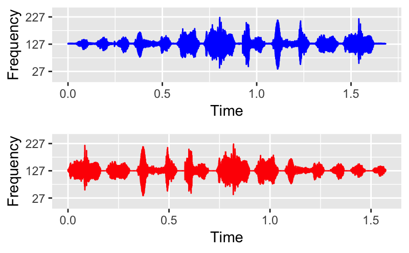

```r
p1 = ggplot() +
  geom_line(aes(x = tim, y = zf_data@left), color = "Blue") +
  scale_y_continuous(name = "Frequency", breaks = c(27,127,227), limits = c(0,250)) +
  scale_x_continuous(name = "Time")
p2 = ggplot() +
  geom_line(aes(x = revtim, y = revordersong), color = "Red") +
  scale_y_continuous(name = "Frequency", breaks = c(27,127,227), limits = c(0,250)) +
  scale_x_continuous(name = "Time")
grid.arrange(p1, p2, nrow = 2)
```

or we can show the spectra…

the orininal signal:

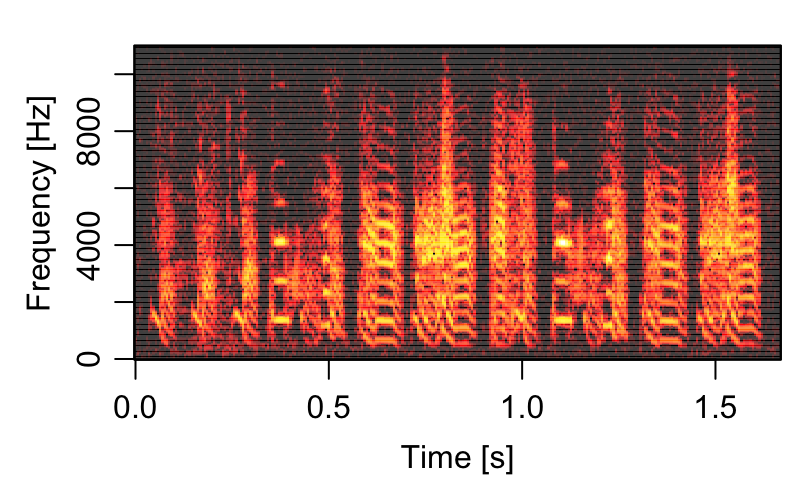

```r
specplot(zf_data, Fs = zfFs)
```

reverse signal:

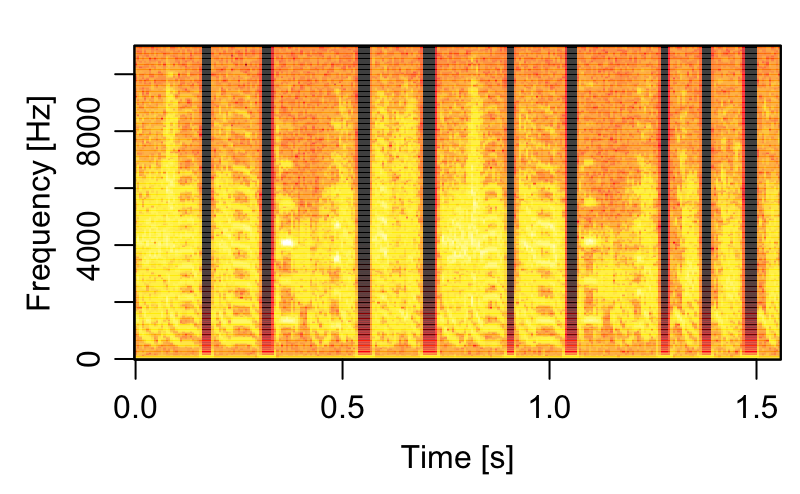

```r
specplot(revordersong, Fs = zfFs)
```

Save the data to a wave file. You can then use Audacity to listen to it.

```r
savewav(revordersong, Fs, "revordersong.wav")
```

# Exercise 11: Make a NEW song with each syllable reversed but the syllable order normal

```r
revsylsong = unlist(syllable[length(syllable)])
```

Now reverse it – we saw how to do this in a previous excerise…

```r
revsylsong = revsylsong[seq(to = 1, by = -1, length.out = length(revsylsong))]
```

Now do the same for the rest of the syllables, adding them to the new variable…

*We use the temporary variable **ra** to do the reversing*

```r
for (l in seq(2, length(syllable), 1)) {

  ra = unlist(syllable[[l]])
  revsylsong = append(revsylsong, unlist(nop[[l]]))
  revsylsong = append(revsylsong, unlist(ra[seq(to = 1, by = -1, length.out = length(syllable[[l]]))]))

}
```

and don’t forget about the time data…

```r
revsyltim = seq(1/Fs, length(revsylsong)/Fs, 1/Fs)
```

Now we can make the same plots as last time, including spectrograms:

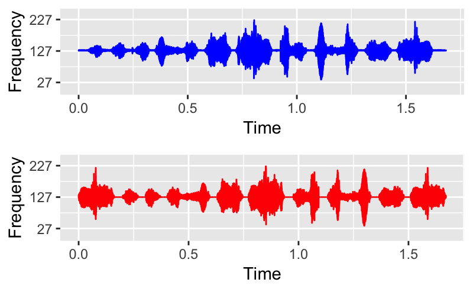

```r
p3 = ggplot() +
  geom_line(aes(x = tim, y = zf_data@left), color = "Blue") +
  scale_y_continuous(name = "Frequency", breaks = c(27,127,227), limits = c(0,250)) +
  scale_x_continuous(name = "Time")
p4 = ggplot() +
  geom_line(aes(x = revsyltim, y = revsylsong), color = "Red") +
  scale_y_continuous(name = "Frequency", breaks = c(27,127,227), limits = c(0,250)) +
  scale_x_continuous(name = "Time")
grid.arrange(p3, p4, nrow = 2)
```

We can save the file as a .wav using the same process as in the last excercise.

```r
savewav(revsylsong, FS, "revsylsong.wav")
```

With these tools you can make a wide range of arbitrary stimuli from your recordings of animal signals. These are powerful tolls for sensory electrophysiology.

### Practice:Try to redo this exercise with the data in wcs.wav.